# PSME Maths Refresher 2018

## Getting started

1. Who am I?
2. Who are you?
   - Name
   - Home country and city
   - Bonus question
3. Remembering names
   - Name on card
   - Photos
4. Questions about PSME
5. Questions about Paris

## General tips

1. Read Cal Newport's books about studying or read his blog at [calnewport.org/blog/](http://calnewport.com/blog/)
2. Think carefully about your plans for Christmas and New Year. Exams are usually in January.
3. First semester is formal and second semester is applied.

## Outline

1. Collection of useful topics
   - Exponents and logs, Summations, Logic, Proofs, Set theory
2. Derivatives
3. Optimization
   - Lagrangian, Kuhn-Tucker, Envelope Theorem
4. Matrices and linear algebra
   - Determinants, Eigenvalues and eigenvectors, Projections, Diagonalization
5. Probability and Statistics
   - Conditional probability, Bayes rule, Expected value, Variances and co-variances, Distributions, Central limit theorem,

## Approach

Maths REFRESHER, what is your responsibility?

Lots and lots and lots of practice.

The get-back-to-this list.

Colloborate. Start a dropbox.

## Class routine

One hour sessions with 10-15 minute breaks

10 minutes late, wait until the next session

Late from breaks, wait until the next session

Phones and computers only as a substitute for textbooks.

## Why do we need mathematics for economics?

Dani Rodrick in *Economics Rules* :

> The reason economists use mathematics is typically misunderstood. It has little to do with sophistication, complexity, or a claim to higher truth. Math essentially plays two roles in economics, neither of which is cause for glory: clarity and consistency.

And always remember that:

> Today, models that are empirically oriented or policy relevant are greatly preferred in top journals over purely theoretical, mathematical exercises. The profession’s stars and most heavily cited economists are those who have shed light on important public problems, such as poverty, public finance, economic growth, and financial crises—not its mathematical wizards.

## Why do you need mathematics for PSME?

Most of the first semester courses require maths. You will use your first semester grades to apply for M2 and perhaps summer internships.

Plans for after PSME?

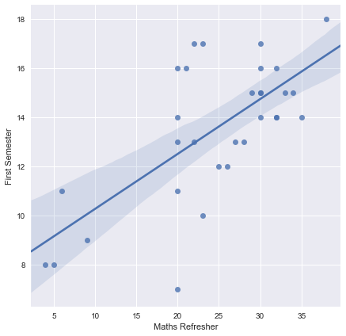

```python
sns.regplot(x="Maths Refresher", y="First Semester", data=psme_grades);
```

## Textbooks

I have used these:

- Chiang, A.C. and Wainwright, K., 2005. *Fundamental methods of mathematical economics*. McGraw-Hill.
- Dowling, E.T., 2011. *Schaum's Outline of Introduction to Mathematical Economics, 3rd Edition*. McGraw-Hill Education.
- Sydsæter, K., Hammond P. and Strøm, A., 2012. *Essential Mathematics for Economic Analysis, 4th Edition*. Pearson.
- Simon, C.P. and Blume, L., 1994. *Mathematics for economists (Vol. 7)*. New York: Norton.

I haven't tried these but they may also be helpful:

- Pemberton, M. and Rau, N., 2015. *Mathematics for economists: an introductory textbook*. Oxford University Press.
- Bergin, J. 2015. *Mathematics for Economists with Applications*. Routledge.
- Hoy, M., Livernois, J., McKenna, C., Rees, R. and Stengos, T., 2011. *Mathematics for economics*. MIT press.

If your mathematical experience exceeds the contents of these textbooks, come chat to me.